# C01-SimpleHarmonicOscillator slides

## Remember

- Hooke's law.
- The simple harmonic oscillator (SHO) equation, $\ddot x + \omega^2 x = 0$.
- For the mass-spring system, what each symbol above represents (acceleration, angular frequency, position, respectively).
- For the mass-spring system, $\omega^2 = k/m$.
- How $\omega$ (the angular frequency), $\nu$ (the frequency) and $T$ (the oscillation period) are related, and the units of each.
- Solutions to the SHO are in the form of $A\sin(\omega t + \phi)$, $A\cos(\omega t + \phi)$, $A_1\sin(\omega t) + A_2\cos(\omega t)$ or any linear combination of these.
- That the three general solution forms above are equivalent, and can be turned into one another.
- That the energy is proportional to the square of the amplitude.
- That energies oscillate at twice the frequency of that of the position and velocity.

## Understand

- What the linear regime means.
- How the SHO equation is assembled for the mass-spring system, and for the LC circuit.
- How the general solution forms above are mathematical representations of the motion (or charge, etc.) or the physical system.
- What the $A$'s and $\phi$ above represent physically.

## Create and apply

- Turn one general solution form above into another, with the help of a trigonometric identity cheat sheet.
- Do quick unit checks as a safeguard against algebra errors.
- From a set of two initial conditions (e.g. initial position **and** initial velocity, for the mass-spring system), how to compute the complete evolution of the system.

For a Flash animation of Hooke's law, follow this link:

https://faraday.physics.utoronto.ca/GeneralInterest/Harrison/Flash/ClassMechanics/HookesLaw/HookesLaw.html

*End of 09/07 lecture, beginning of 09/10 lecture.*

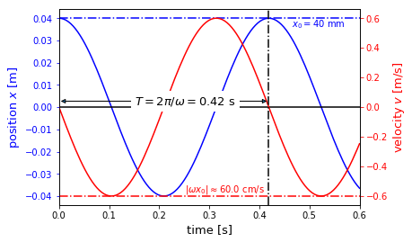

```python
plt.show()
```

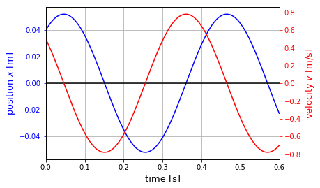

```python
plt.show()
```

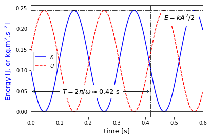

```python
plt.show()
```

[figure not shown]

| Mass+spring | LC circuit |
| --- | --- |
| $x$ | $q$ |
| $v$ | $I$ |
| $m$ | $L$ |
| $k$ | $1/C$ |
| KE $K = mv^2/2$ | Magnetic energy $LI^2/2$ |
| PE $U = kx^2/2$ | Electrostatic energy $CV_C^2/2$ |